# Reproducible Research: Peer Assessment 1

## Loading and preprocessing the data

```r
library(dplyr)
library(lattice)
df<-read.csv("activity.csv", na.strings="NA")
df$date<-as.Date(df$date, "%Y-%m-%d")
```

## What is mean total number of steps taken per day?

1. Calculate the total number of steps taken per day:

```r
total_steps<-aggregate(df$steps, list(df$date), FUN=sum,
                       na.rm=TRUE)
colnames(total_steps)<-c("date", "steps")
```

2. Make a histogram of the total number of steps taken each day:

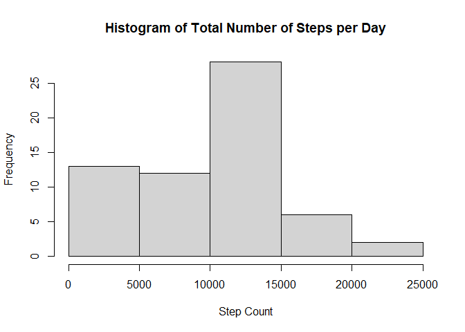

```r
hist(total_steps$steps, main="Histogram of Total Number of Steps per Day",
     xlab="Step Count")
```

3. Calculate and report the mean and median of the total:

```r
step_mean<-mean(total_steps$steps, na.rm=TRUE)
step_median<-median(total_steps$steps, na.rm=TRUE)
```

The mean is 9354.2295082 and the median is 10395.

## What is the average daily activity pattern?

1. Make a time series plot of the 5-minute interval and the average number of steps taken, averaged across all days:

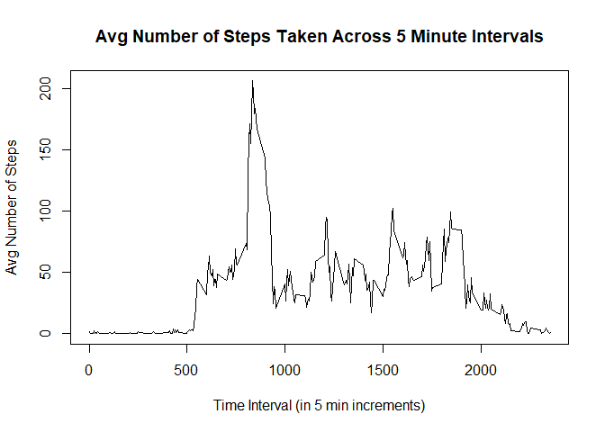

```r
avg_interval<-aggregate(df$steps, list(df$interval), FUN=mean,
                        na.rm=TRUE)
colnames(avg_interval)<-c("interval", "avg_steps")
plot(avg_interval$interval, avg_interval$avg_steps, type="l",
     main="Avg Number of Steps Taken Across 5 Minute Intervals",
     xlab="Time Interval (in 5 min increments)",
     ylab="Avg Number of Steps")
```

2. Which 5-minute interval, on average across all the days in the dataset, contains the maximum number of steps?

```r
i<-which.max(avg_interval$avg_steps) #index of max steps
int<-avg_interval$interval[i] # find interval
int
```

```
## [1] 835
```

Answer: The interval 835 contains the maximum number of steps.

## Imputing missing values

1. Calculate and report the total number of missing values in the dataset.

```r
miss<-sum(is.na(df))
miss
```

```
## [1] 2304
```

Answer: There are 2304 missing values in the dataset.

2. Devise a strategy for filling in all of the missing values. Answer: For any missing data, I will fill in the mean for the applicable 5-minute interval.
3. Create a new dataset that is equal to the original dataset by with the missing data filled in.

```r
d2<-data.frame(df)
for (i in 1:nrow(d2)) {
    if (is.na(d2$steps[i])) {
        inter<-d2$interval[i]
        myrow<-filter(avg_interval, avg_interval$interval==inter)
        d2$steps[i]<-myrow$avg_steps
    }
}
head(d2)
```

```
##       steps       date interval
## 1 1.7169811 2012-10-01        0
## 2 0.3396226 2012-10-01        5
## 3 0.1320755 2012-10-01       10
## 4 0.1509434 2012-10-01       15
## 5 0.0754717 2012-10-01       20
## 6 2.0943396 2012-10-01       25
```

```r
total_steps2<-aggregate(d2$steps, list(d2$date), FUN=sum,
                       na.rm=TRUE)
colnames(total_steps2)<-c("date", "steps")
```

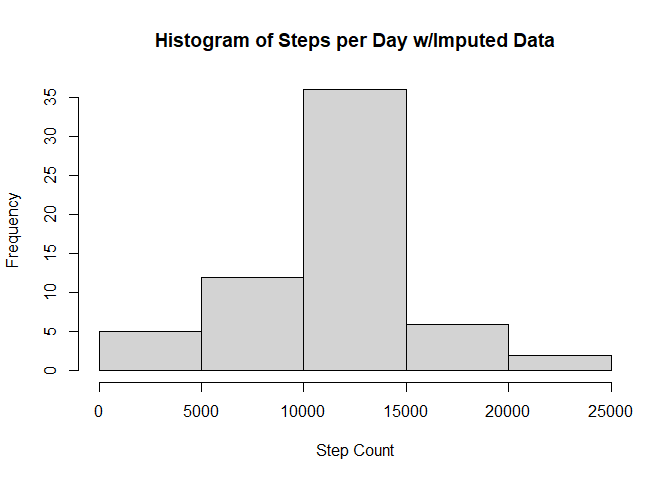

```r
hist(total_steps2$steps, main="Histogram of Steps per Day w/Imputed Data",
     xlab="Step Count")
```

```r
step_mean2<-mean(total_steps2$steps, na.rm=TRUE)
step_median2<-median(total_steps2$steps, na.rm=TRUE)
```

## Are there differences in activity patterns between weekdays and weekends?

1. Create a new factor variable in the dataset with two levels – “weekday” and “weekend” indicating whether a given date is a weekday or weekend day.

```r
d2$weekdays<-factor(format(d2$date, '%A'))
levels(d2$weekdays)
```

```
## [1] "Friday"    "Monday"    "Saturday"  "Sunday"    "Thursday"  "Tuesday"
## [7] "Wednesday"
```

```r
levels(d2$weekdays)<-list("weekday"= c("Monday", "Tuesday", "Wednesday", "Thursday",
                                      "Friday"), "weekend"=c("Saturday", "Sunday"))
avg_interval2<-aggregate(d2$steps, list(d2$weekdays, d2$interval), FUN=mean,
                        na.rm=TRUE)
colnames(avg_interval2)<-c("day", "interval", "steps")
```

2. Make a panel plot containing a time series plot (i.e. type = “l”) of the 5-minute interval (x-axis) and the average number of steps taken, averaged across all weekday days or weekend days (y-axis).

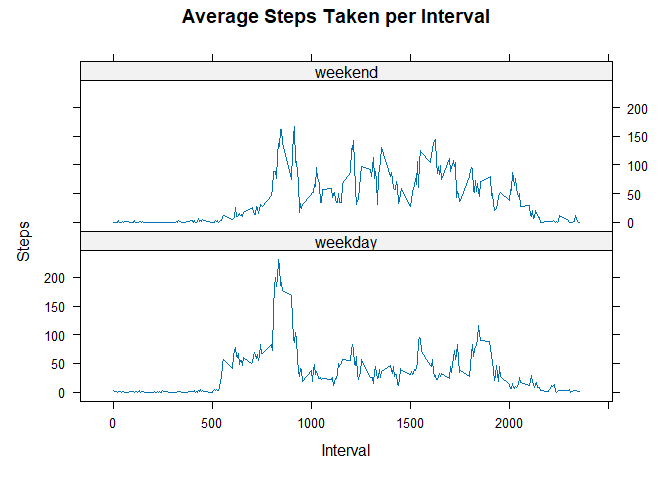

```r
g<-xyplot(avg_interval2$steps ~ avg_interval2$interval | avg_interval2$day, data=avg_interval2,
       layout=c(1,2), type="l", xlab="Interval", ylab="Steps", main="Average Steps Taken per Interval")
g
```